# Assignment2

```r
library(tidyverse)
```

# Q1

### a) Read in and display (some of) the data.

```r
url = "http://ritsokiguess.site/datafiles/gas-mileage.csv"
a <- read_csv(url)
head(a)
```

| mpg |
| --- |
| 41.5 |
| 50.7 |
| 36.6 |
| 37.3 |
| 34.2 |
| 45.0 |

### b) Make a suitable graph of this dataset.

I choose histogram

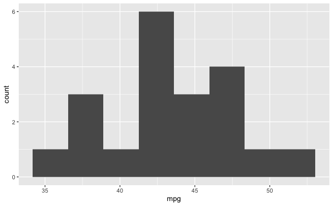

```r
ggplot(data = a, aes(x = mpg)) + geom_histogram(bins = 8)
```

### c) What does your graph tell you about the distribution of values of fuel efficiency? Explain briefly.

The center of the distribution of values of fuel efficiency is about 40 - 45. The distribution of fuel efficiency is a little bit skewed to the left in the histogram. The distribution of fuel efficiency is relatively concentrated (ranging from 30-55) and there is no obvious outlier.

### d) Would you feel comfortable using a confidence interval for the mean fuel efficiency based on the t-distribution, or not? Explain briefly.

The t-test is usable in this question. Because by Central Limit Theorem, the distribution of the means will be normal when the sample size is large enough. Therefore, for the sample size 20, the distribution of the means will be normal and the t-test is usable.

### e) Obtain a 90% confidence interval for the mean fuel efficiency. (Do this even if you think this is not appropriate; the point of this part is to have you practice the procedure.)

```r
t.test(a, conf.level = 0.9)
```

```
    One Sample t-test

data:  a
t = 43.729, df = 19, p-value < 2.2e-16
alternative hypothesis: true mean is not equal to 0
90 percent confidence interval:
 41.46298 44.87702
sample estimates:
mean of x
    43.17
```

The 90% CI for the mean fuel efficiency is (41.46,44.88).

# Q2

### a) Read in and display (some of) the data.

```r
url <- "http://ritsokiguess.site/datafiles/student_survey.csv"
student_survey <- read_csv(url)
head(student_survey)
```

| studying | tv_watching | sleep_hours |
| --- | --- | --- |
| arts | 3 | 4 |
| arts | 3 | 9 |
| arts | 1 | 8 |
| arts | 1 | 7 |
| arts | 1 | 8 |
| arts | 0 | 6 |

### b) For TV watching, obtain the sample size, sample mean, and sample standard deviation for the students in each area of study.

```r
student_survey %>% group_by(studying) %>% summarise(sample_size = n(), average_tv_watching = mean(tv_watching), SD = sd(tv_watching))
```

| studying | sample_size | average_tv_watching | SD |
| --- | --- | --- | --- |
| arts | 39 | 2.538462 | 2.817671 |
| science | 116 | 1.663793 | 1.641547 |

### c) Is there evidence that the mean numbers of hours spent watching TV are different between the two groups of students? Run a Welch test, and comment briefly on the results.

```r
t.test(data = student_survey,  tv_watching~studying)
```

```
    Welch Two Sample t-test

data:  tv_watching by studying
t = 1.8366, df = 46.965, p-value = 0.0726
alternative hypothesis: true difference in means between group arts and group science is not equal to 0
95 percent confidence interval:
 -0.08341417  1.83275104
sample estimates:
   mean in group arts mean in group science
             2.538462              1.663793
```

We read that p-value = 0.0726. The p-value is greater than 0.05, so the result is non-significant. Therefore, there isn’t enough evidence to prove there is difference in the mean TV watching time between arts or science students.

### d) Repeat the previous part, only this time running a pooled t-test.

```r
t.test(data = student_survey,  tv_watching~studying, var.equal = TRUE)
```

```
    Two Sample t-test

data:  tv_watching by studying
t = 2.3635, df = 153, p-value = 0.01936
alternative hypothesis: true difference in means between group arts and group science is not equal to 0
95 percent confidence interval:
 0.1435589 1.6057780
sample estimates:
   mean in group arts mean in group science
             2.538462              1.663793
```

We read that p-value = 0.01936. The p-value is smaller than 0.05, so we we reject H0. Therefore, the mean numbers of hours spent watching TV for arts or science students are different.

### e) Which of the two tests you did in the previous two parts is the more appropriate? Explain briefly.

The c) part is more appropriate because the sample standard deviation for the students in different study area is different (one is 2.8 and another is 1.6), it is not appropriate to assume the variance are equal when doing pooled t-test. So the Welch test, which is the unpooled t-test, is more appropriate.

### f) What do the results in this question indicate about the effect of (mistakenly) using the pooled test instead of the Welch test when the pooled test is not appropriate? (The conclusion, though it has only been observed in one dataset here, does actually apply generally.) Hint: the means don’t affect what happens.

We are more likely to making a TYPE 1 error: If we use the pooled test incorrectly, meaning that we wrongly assume that the variances are equal, the calculated p-value will be smaller than it should be. So the probability that we’re going to incorrectly reject H0 is going to be higher.